# Webpage

Carolyn Kurle

January 17, 2019

Call in the libraries you’re going to use for this session. Add the warning = F, message = F

Go back to this library chunk if you ever need to pull in more libraries

```r
library (dplyr)
library (tidyr)
library (ggplot2)
library (DT)
library (leaflet)
```

We are reading in some salmon escapment data. From Alaska Department of Fish and Game, Division of Commercial Fisheries. 2017. Daily salmon escapement counts from the OceanAK database, Alaska, 1921-2017. Knowledge Network for Biocomplexity. doi:10.5063/F1S46Q6M.

```r
esc <- read.csv(url("https://knb.ecoinformatics.org/knb/d1/mn/v2/object/urn%3Auuid%3Af119a05b-bbe7-4aea-93c6-85434dcb1c5e", method = "libcurl"),
               stringsAsFactors = F)

head(esc)
```

```
##        Location SASAP.Region sampleDate Species DailyCount  Method
## 1 Akalura Creek       Kodiak 1930-05-24 Sockeye          4 Unknown
## 2 Akalura Creek       Kodiak 1930-05-25 Sockeye         10 Unknown
## 3 Akalura Creek       Kodiak 1930-05-26 Sockeye          0 Unknown
## 4 Akalura Creek       Kodiak 1930-05-27 Sockeye          0 Unknown
## 5 Akalura Creek       Kodiak 1930-05-28 Sockeye          0 Unknown
## 6 Akalura Creek       Kodiak 1930-05-29 Sockeye          0 Unknown
##   Latitude Longitude Source
## 1  57.1641 -154.2287   ADFG
## 2  57.1641 -154.2287   ADFG
## 3  57.1641 -154.2287   ADFG
## 4  57.1641 -154.2287   ADFG
## 5  57.1641 -154.2287   ADFG
## 6  57.1641 -154.2287   ADFG
```

Calculate annual, regional total escapement

- ‘separate’ date into year - month - day. The c is the concatenate function and so you put your separations into “”. The separator is the dash. It returned the data as characters (chr). We want to turn the year into a numeric value.
- ‘group_by’ and ‘summarize’ to calculate the sm over unique region-year-species combinations

Filter species %in% which is useful when you need to group “or” into a list. Otherwise you’d have to type or between each species

```r
annual_esc <- esc %>%
  separate(sampleDate, into = c("Year", "Month", "Day"), sep = '-') %>%
  mutate(Year = as.numeric(Year)) %>%
  group_by(SASAP.Region, Species, Year) %>%
  summarise(escapement = sum(DailyCount)) %>%
  filter(Species %in% c("Chinook", "Sockeye", "Pink", "Chum", "Coho"))

head(annual_esc)
```

```
## # A tibble: 6 x 4
## # Groups:   SASAP.Region, Species [1]
##   SASAP.Region                          Species  Year escapement
##   <chr>                                 <chr>   <dbl>      <int>
## 1 Alaska Peninsula and Aleutian Islands Chinook  1974       1092
## 2 Alaska Peninsula and Aleutian Islands Chinook  1975       1917
## 3 Alaska Peninsula and Aleutian Islands Chinook  1976       3045
## 4 Alaska Peninsula and Aleutian Islands Chinook  1977       4844
## 5 Alaska Peninsula and Aleutian Islands Chinook  1978       3901
## 6 Alaska Peninsula and Aleutian Islands Chinook  1979      10463
```

WE are going to create a data table of our data. An interactive table. We need DT library to do this. So I called that library in above in my library chunk and executed that chunk.

If you don’t want to show all of these details in your knitted file, you can set echo = false in your initial {r} part. It would be: ‘’’{r, echo = F}

```r
datatable(annual_esc)
```

|  | SASAP.Region | Species | Year | escapement |
| --- | --- | --- | --- | --- |
| 1 | Alaska Peninsula and Aleutian Islands | Chinook | 1974 | 1092 |
| 2 | Alaska Peninsula and Aleutian Islands | Chinook | 1975 | 1917 |
| 3 | Alaska Peninsula and Aleutian Islands | Chinook | 1976 | 3045 |
| 4 | Alaska Peninsula and Aleutian Islands | Chinook | 1977 | 4844 |
| 5 | Alaska Peninsula and Aleutian Islands | Chinook | 1978 | 3901 |
| 6 | Alaska Peninsula and Aleutian Islands | Chinook | 1979 | 10463 |
| 7 | Alaska Peninsula and Aleutian Islands | Chinook | 1980 | 4506 |
| 8 | Alaska Peninsula and Aleutian Islands | Chinook | 1981 | 5046 |
| 9 | Alaska Peninsula and Aleutian Islands | Chinook | 1982 | 6503 |
| 10 | Alaska Peninsula and Aleutian Islands | Chinook | 1983 | 11589 |

[output cut: 1474 more lines]

# ggplot

aes is a function that stands for aesthetics. The aes function will map the columns in the data frame to wherever you want them to go in th eplot. The X or Y axis or the color you want to assign to variables. It tells ggplot which columns to pick from your data frame and how to map them onto your plot.

We’re comparing escapment by species first so x = species, y = escapement

Then we’ll add some geometries with the function geom col. You use a + because you’re going to add your data in a column format. You’re telling it to add the annual escapement data by species in column format. There are lots of different function calls you could use to make different kind of plots. You use the “+” instead of the pipe %>% that dplyr uses. Typing ?geom_ into the console will bring up a huge list of different plot types.

You can use different commands to color it, etc. But don’t include that in your aesthetic mapping call. It’s looking for a column called blue, it can’t find it, so it’s made a column called blue on the back end of the data. To change properties of the table that aren’t mapped to variables, they have to be inside the geom call, but not inside the aes call.

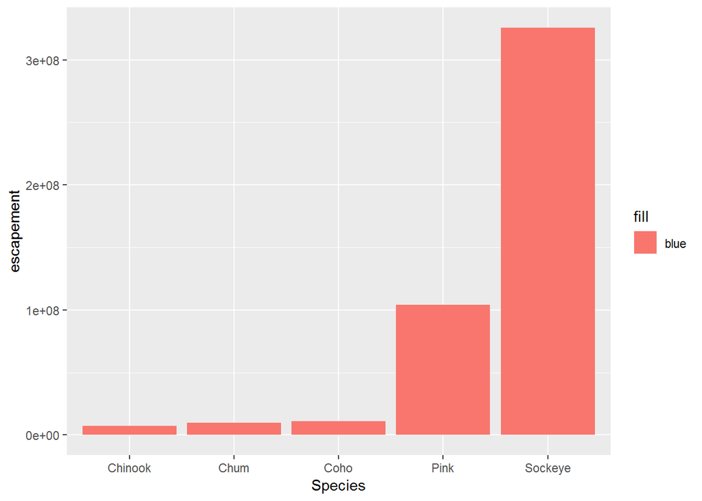

```r
ggplot(data = annual_esc, mapping = aes(x = Species, y = escapement, fill = "blue")) +
  geom_col()
```

We’ll change this here so now it makes the columns blue.

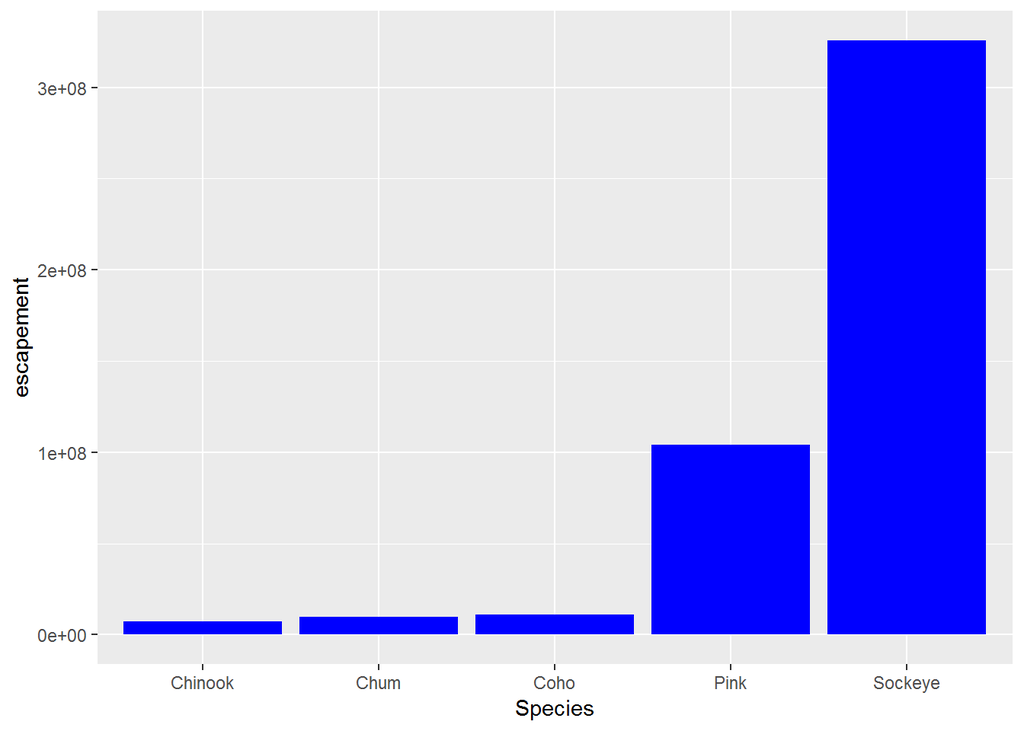

```r
ggplot(data = annual_esc, mapping = aes(x = Species, y = escapement)) +
  geom_col(fill = "blue")
```

You can also make them different colors by species

Data Visualization with ggplot2 cheatsheet will help you figure out all the options for everything. Changing colors, etc. Those will be in the Help, Cheatsheets above.

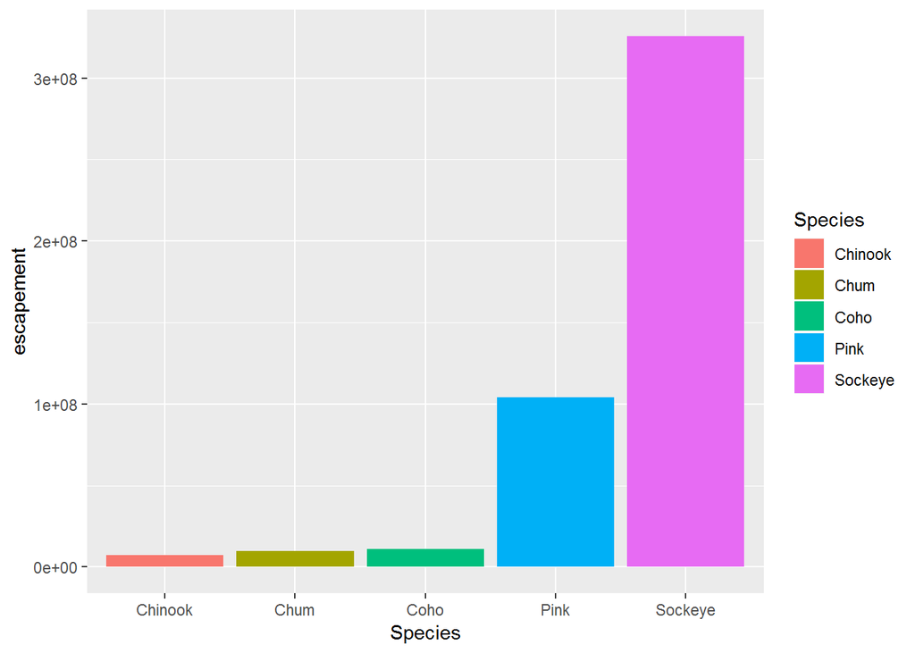

```r
ggplot(data = annual_esc, mapping = aes(x = Species, y = escapement, fill = Species)) +
  geom_col()
```

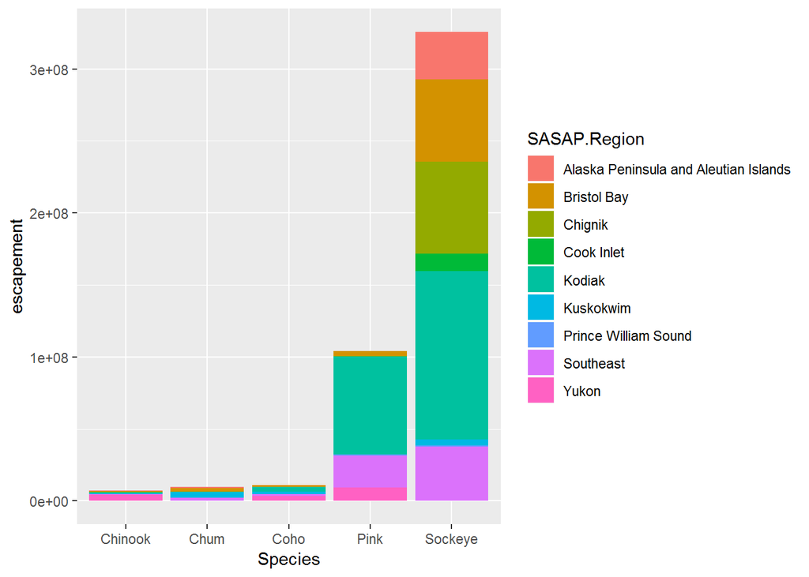

```r
ggplot(data = annual_esc, mapping = aes(x = Species, y = escapement, fill = SASAP.Region)) +
  geom_col()
```

Now we might to only look at the Kodiak Data

Create a timeseries of Kodiak Escapement by Species

We want to color it by species. We use color for fonts and symbols. We use fill to fill colors of bars, etc. I’ve nested the functions inside of my ggplot call, but you could also create a new data frame with only the Kodiak data using dplyr functions and then do the plotting. sometimes it makes sense to do that. Especially if you’re going to do a lot of plotting with only those data. Then you don’t have to filter it each time. Just depends what you want to do. Creating tons of data frames may be unwelcome or unnecessary.

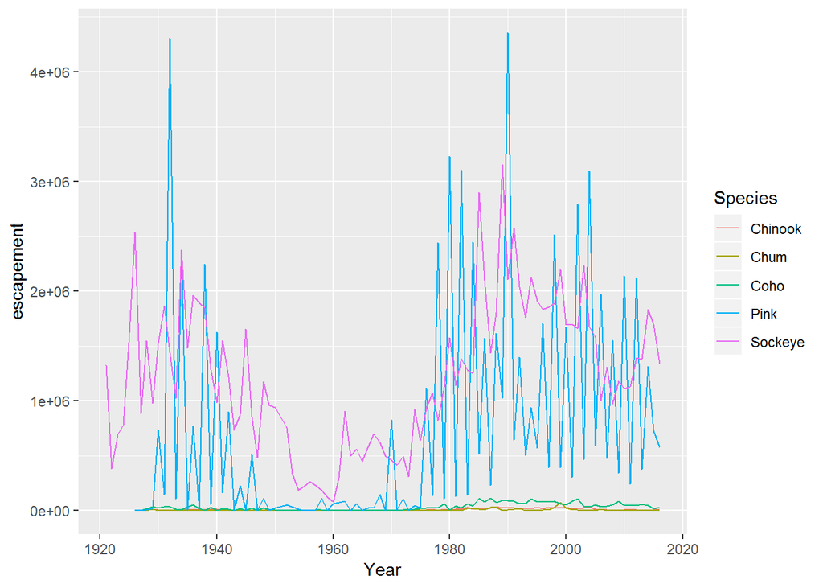

```r
ggplot(data = filter(annual_esc, SASAP.Region == "Kodiak"),
       aes(x = Year, y = escapement, color = Species)) +
  geom_line()
```

Now we can add multiple geometries onto a plot. Say we want to know where the actual points are. Add the geom_point funtion.

You could change the x and y labels. Or the Title. You just have to be sure to add all of the function calls onto your ggplot object with that plus sign (+). Special characters can be difficult to add, but you can use the unicode character for whatever you want. That’s in your keyboard somewhere by holding down the alt key and typing in a number string (Google this).

It also has a bunch of themes you can use to set a bunch of properties on the plot. It will make the background white or add a border or take away a border, etc. Type theme_ and a bunch of choices will come up. You can also use theme to call up specific calls like title, etc. Google what you want to do in ggplot2 using the different themes and then you can add theme calls into your code to center the title or whatever you want to do. You can also create a my_theme set of rubrics that you always like to use, then add that bit of code into your ggplot at the beginning and it will apply that to all your plots.

For example: my_theme <- theme_bw() + theme(plot.title = element_text(hjust = 0.5))

This creates an object that you’ve defined for R and now you just have to type my_theme when you want to use those theme elements for your plots.

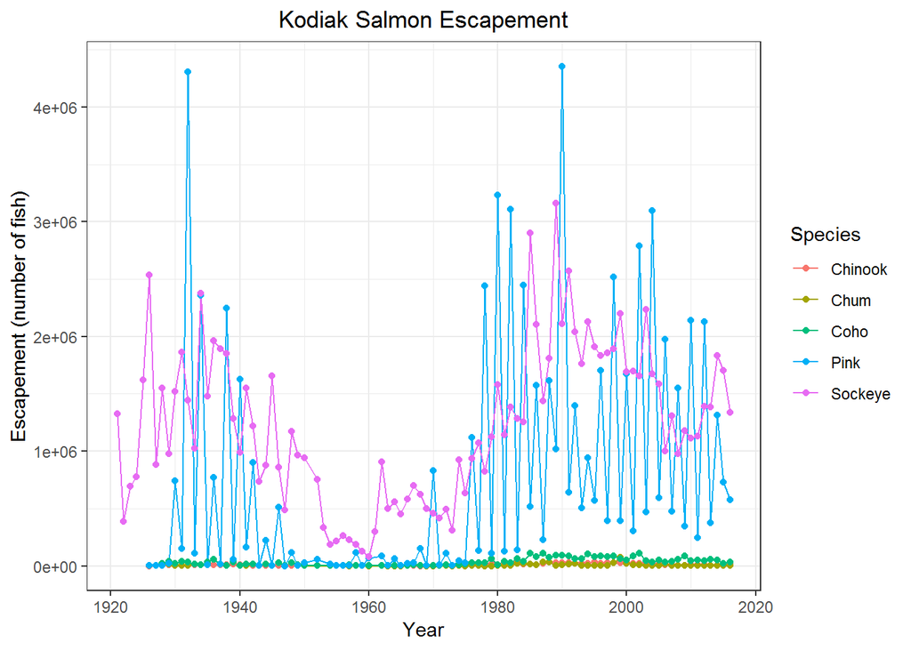

```r
ggplot(data = filter(annual_esc, SASAP.Region == "Kodiak"),
       aes(x = Year, y = escapement, color = Species)) +
  geom_line() +
  geom_point() +
  ylab("Escapement (number of fish)") +
  ggtitle("Kodiak Salmon Escapement") +
  theme_bw() +
  theme(plot.title = element_text(hjust = 0.5))
```

Plot timeseries of escapement by species for all regions. We’re going to use the function facet wrap within ggplot. This allows us to create a bunch of plots at once. The ~ syntax tells it to compare multiple x and Y axes. In this case, it’s breaking them out by SASAP Region.

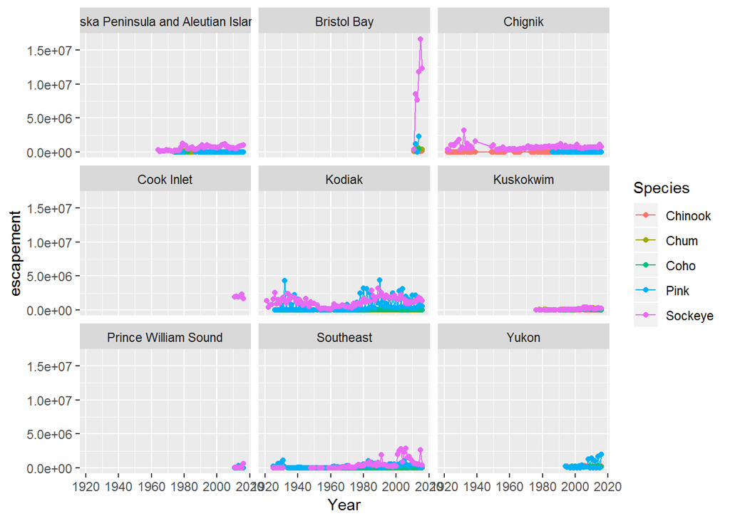

```r
ggplot(annual_esc, aes(x = Year, y = escapement, color = Species)) +
  geom_line() +
  geom_point() +
  facet_wrap(~SASAP.Region)
```

You can change the y axes per plot or the x axes per plot or the width and height.

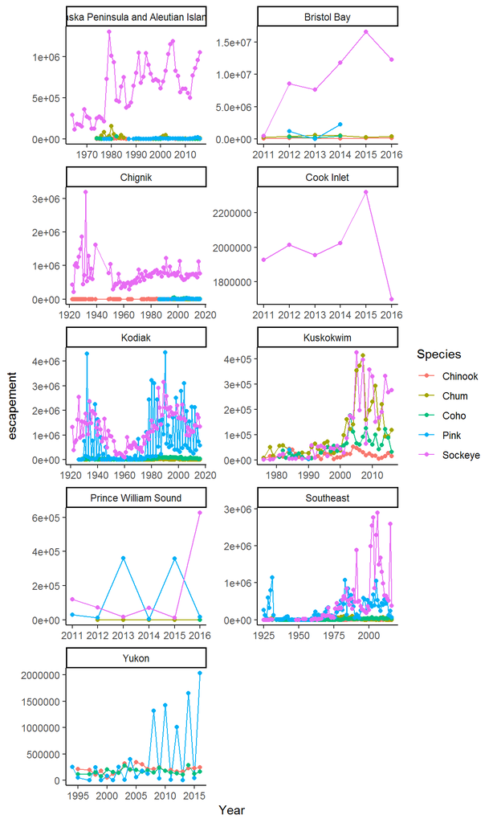

```r
ggplot(annual_esc, aes(x = Year, y = escapement, color = Species)) +
  geom_line() +
  geom_point() +
  facet_wrap(~SASAP.Region, scales = "free", ncol = 2)+
  theme_classic()
```

To save a plot. This ggsave saves only the latest plot you’ve made.

It saves it to your top level directory. You could create a new folder for Figures and save it to that (ggsave(“figures/region_escapement.png”)) if that’s cleaner.

Also, you can save it as another type (jpg or tif or whatever you like)

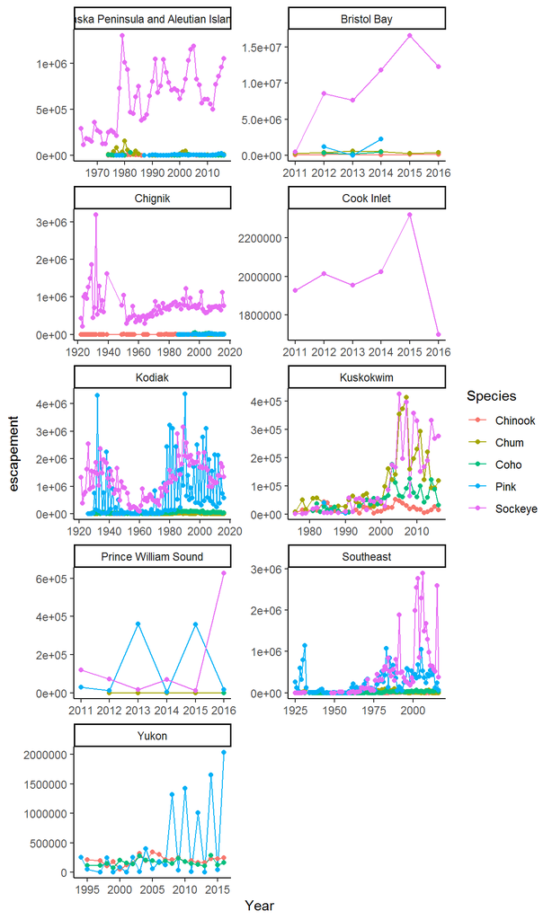

```r
ggplot(annual_esc, aes(x = Year, y = escapement, color = Species)) +
  geom_line() +
  geom_point() +
  facet_wrap(~SASAP.Region, scales = "free", ncol = 2)+
  theme_classic()
```

```r
ggsave("region_escapement.png",
       height = 10,
       width = 8,
       units = "in")
```

If you want to save a new or amended data frame to your harddrive, create a new folder in your files pane to the right, then do this code: It’s the write.csv funtion.

You may not want to add this to your github directories as it’s too big. You could add a gitignore command.

```r
write.csv(annual_esc,
          "derived_data/annual_escapement.csv",
          row.names = F)
```

# Interactive map using Leaflet

First we’ll add the library leaflet to our library call list at the top.

We’re going to make a map using leaflet

*Find unique locations with lat and long values

Create a new data frame called locations

We’ll use distinct from tdyr

```r
locations <- esc %>%
  distinct(Location, Latitude, Longitude)

datatable(locations)
```

|  | Location | Latitude | Longitude |
| --- | --- | --- | --- |
| 1 | Akalura Creek | 57.1641 | -154.2287 |
| 2 | Anan Creek |  |  |
| 3 | Andrews Creek |  |  |
| 4 | Anvik River | 62.7 | -160.2 |
| 5 | Auke Creek |  |  |
| 6 | Ayakulik River | 57.1956 | -154.529 |
| 7 | Bear Creek | 56.0389 | -160.2734 |
| 8 | Bear River | 56.0389 | -160.2734 |
| 9 | Big Bay Creek | 58.5426 | -152.5683 |
| 10 | Big Kitoi Creek | 58.1915 | -152.3754 |

[output cut: 138 more lines]

There are missing lat and long values so we can fix that using drop na function from tidyr. This will drop all NAs in your data set, so beware of this. In our case, we don’t care as we’re only working with Lat and Long NAs in this example.

```r
locations <- esc %>%
  distinct(Location, Latitude, Longitude) %>%
  drop_na()

datatable(locations)
```

|  | Location | Latitude | Longitude |
| --- | --- | --- | --- |
| 1 | Akalura Creek | 57.1641 | -154.2287 |
| 4 | Anvik River | 62.7 | -160.2 |
| 6 | Ayakulik River | 57.1956 | -154.529 |
| 7 | Bear Creek | 56.0389 | -160.2734 |
| 8 | Bear River | 56.0389 | -160.2734 |
| 9 | Big Bay Creek | 58.5426 | -152.5683 |
| 10 | Big Kitoi Creek | 58.1915 | -152.3754 |
| 12 | Black Lake | 56.392 | -158.937 |
| 13 | Buskin River | 57.7768 | -152.5372 |
| 14 | Chelatna Lake | 62.4731 | -151.4545 |

[output cut: 58 more lines]

Now we’ll create the Leaflet map

Leaflet uses the pipe symbol.

we use the addTiles function to create the actual map. This addTiles function uses your locations that you’ve included to know what map to create. If I had locations in WA, it would zoom out the map.

The add markers puts your actual locations on the map. And this also sets the parameters for your map so it knows to constrain your map to those points. Without that, it doesn’t know how to constrain your map.

The popups allow whatever you want to pop up when you toggle onto the individual points. You can include hyper links, images, etc.

```r
leaflet(locations) %>%
  addTiles() %>%
  addMarkers(~ Longitude, ~Latitude, popup = ~ Location)
```

[interactive chart not shown]